# Data Wrangling and Husbandry

4/30/2018

## Dataset

Dataset –> Olympics data.

- Data from Kaggle. (https://www.kaggle.com/rio2016/olympic-games/data)
- Scraped data from Wikipedia. (https://en.wikipedia.org/wiki/2016_Summer_Olympics_medal_table)
- Scraped data from Olympic database. (http://www.theolympicdatabase.nl/home)

Two data sources contain 2016 Olympics data and the other one has overall medals obtained by each country from start of the Olympics till 2016.

## Scraping and Loading Data

```
## # A tibble: 5 x 12
##        id name    nationality sex   dob   height weight sport  gold silver
##     <int> <chr>   <chr>       <chr> <chr>  <dbl>  <int> <chr> <int>  <int>
## 1  7.36e8 A Jesu~ ESP         male  10/1~   1.72     64 athl~     0      0
## 2  5.32e8 A Lam ~ KOR         fema~ 9/23~   1.68     56 fenc~     0      0
## 3  4.36e8 Aaron ~ CAN         male  5/27~   1.98     79 athl~     0      0
## 4  5.21e8 Aaron ~ MDA         male  1/2/~   1.83     80 taek~     0      0
## 5  3.39e7 Aaron ~ NZL         male  11/2~   1.81     71 cycl~     0      0
## # ... with 2 more variables: bronze <int>, total <int>
```

```
## # A tibble: 5 x 4
##   country         nationality population gdp_per_capita
##   <chr>           <chr>            <int>          <dbl>
## 1 Afghanistan     AFG           32526562            594
## 2 Albania         ALB            2889167           3945
## 3 Algeria         ALG           39666519           4206
## 4 American Samoa* ASA              55538             NA
## 5 Andorra         AND              70473             NA
```

Scraped the 2016 Olympics medal table from wikipedia and cleaned the data.

2016 Medal table

```
## # A tibble: 6 x 6
##   Rank  Country                    Gold Silver Bronze Total
##   <chr> <chr>                     <int>  <int>  <int> <int>
## 1 1     United States of America     46     37     38   121
## 2 2     United Kingdom               27     23     17    67
## 3 3     China                        26     18     26    70
## 4 4     Russia                       19     17     19    55
## 5 5     Germany                      17     10     15    42
## 6 6     Japan                        12      8     21    41
```

Scraping…

Overall Medal Table

```
## # A tibble: 6 x 6
##   Rank  Country       Gold  Silver Bronze Total
##   <chr> <chr>         <chr> <chr>  <chr>  <dbl>
## 1 1     United States 1008  811    700     2519
## 2 2     Soviet Union  473   376    356     1205
## 3 3     Germany       259   282    283      824
## 4 4     Italy         226   188    208      622
## 5 5     France        217   237    264      718
## 6 6     Great Britain 215   258    264      737
```

Male to Female Ratio in 2016 Olympics

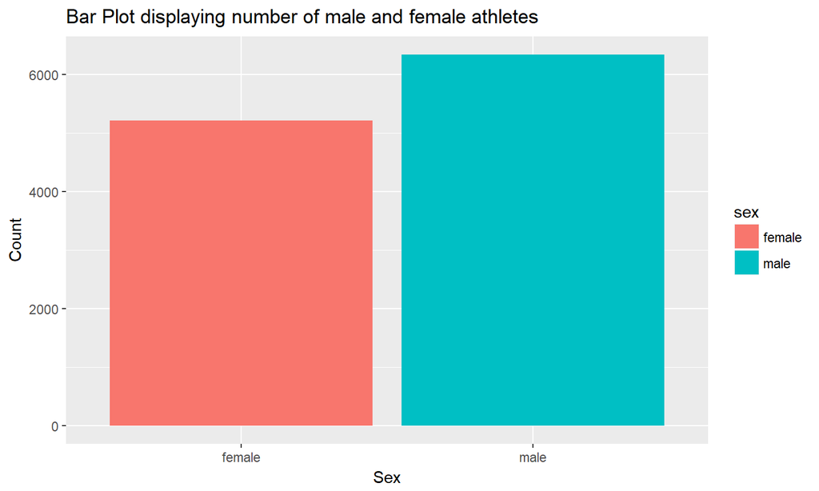

Total number of athletes for each sport

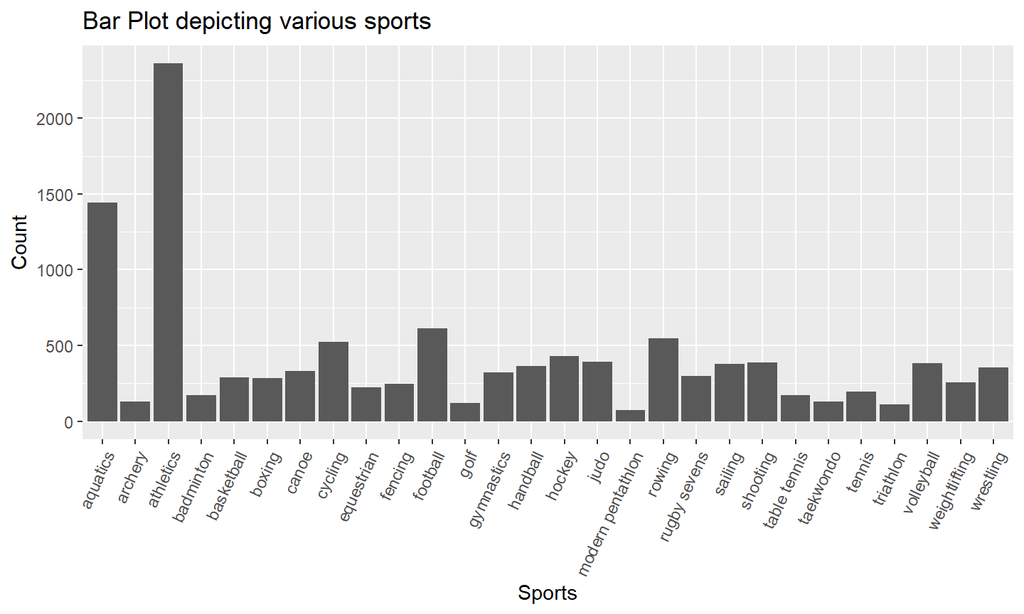

For each sport in the olympics which country is producing highest number of athletes.

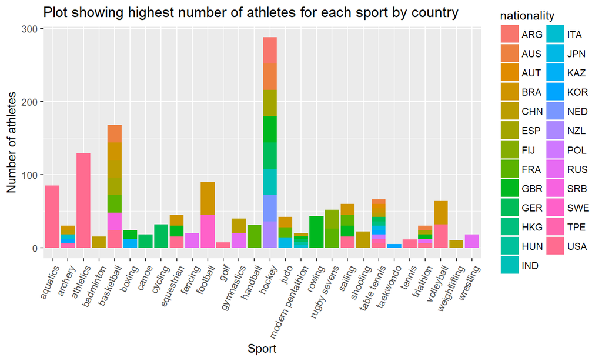

Weight distribution of players for each sport

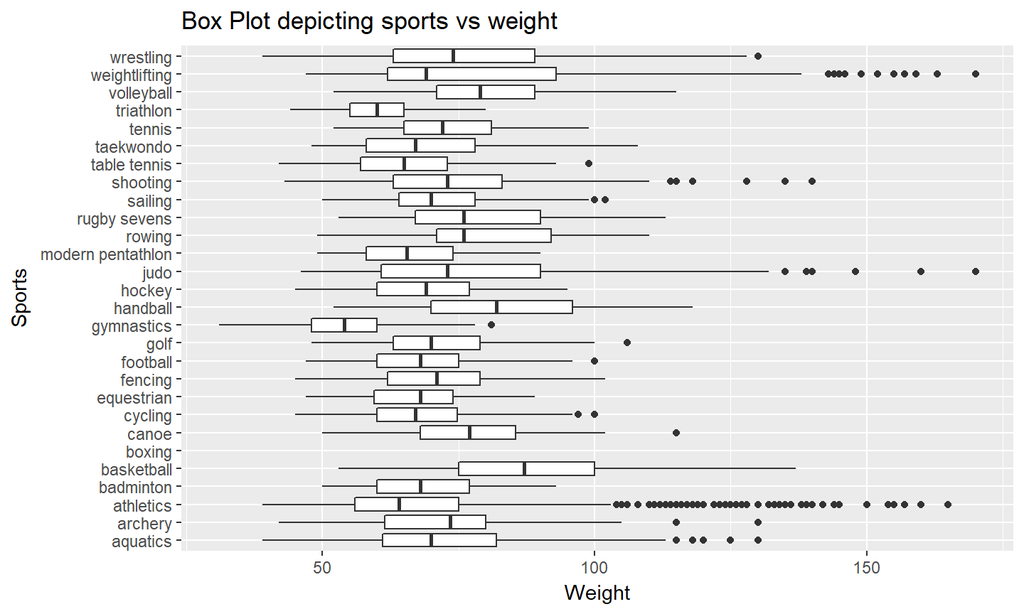

Mean height vs weight for all the sports.

Lowest heights and weights are from Gymnastics.

And, highest values are recorded from Basketball.

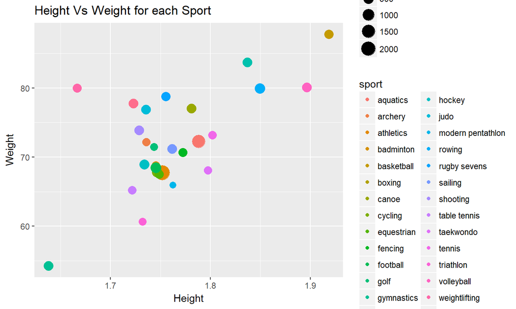

Top 10 countries with Gold medals

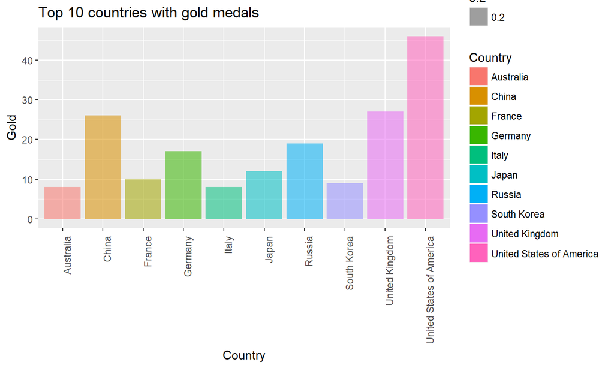

Top 10 countries with Silver medals

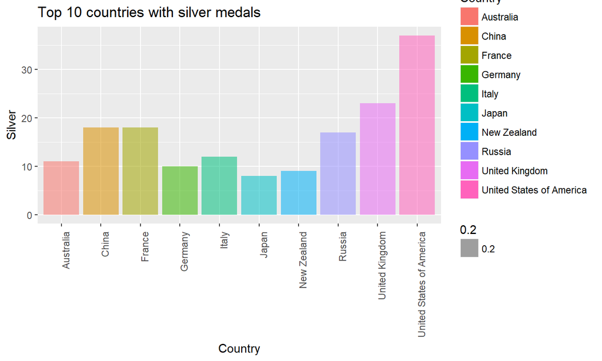

Top 10 countries with Bronze medals

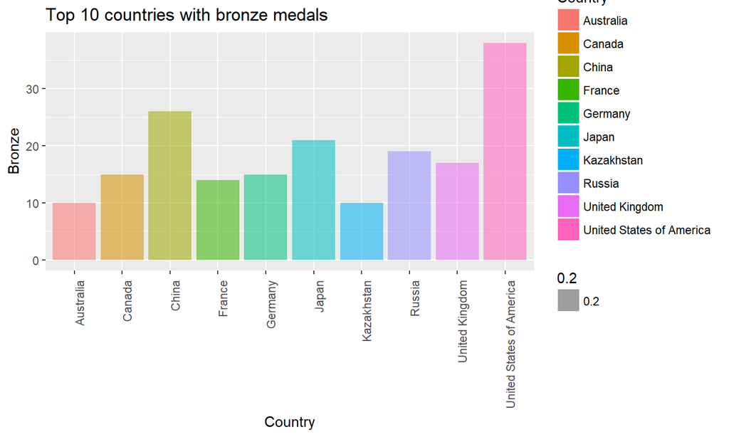

AthleteRatio - Ratio of number of athletes to population.

Top 10 nations with highest AthleteRatio

```
## # A tibble: 10 x 6
##    country        nationality population gdp_per_capita   ath athleteRatio
##    <chr>          <chr>            <int>          <dbl> <int>        <dbl>
##  1 Palau          PLW              21291          13499     5    0.000235
##  2 Nauru          NRU              10222           9828     2    0.000196
##  3 San Marino     SMR              31781             NA     5    0.000157
##  4 British Virgi~ IVB              30117             NA     4    0.000133
##  5 Saint Kitts a~ SKN              55572          15772     7    0.000126
##  6 Bermuda*       BER              65235             NA     8    0.000123
##  7 Seychelles     SEY              92900          15476    10    0.000108
##  8 Antigua and B~ ANT              91818          13715     9    0.0000980
##  9 Cayman Island~ CAY              59967             NA     5    0.0000834
## 10 Liechtenstein  LIE              37531             NA     3    0.0000799
```

Top 10 nations with lowest AthleteRatio

```
## # A tibble: 10 x 6
##    country        nationality population gdp_per_capita   ath athleteRatio
##    <chr>          <chr>            <int>          <dbl> <int>        <dbl>
##  1 Pakistan       PAK          188924874           1435     7 0.0000000371
##  2 Bangladesh     BAN          160995642           1212     7 0.0000000435
##  3 Congo, Dem Rep COD           77266814            456     4 0.0000000518
##  4 Afghanistan    AFG           32526562            594     3 0.0000000922
##  5 India          IND         1311050527           1598   123 0.0000000938
##  6 Indonesia      INA          257563815           3346    28 0.000000109
##  7 Yemen          YEM           26832215           1406     3 0.000000112
##  8 Philippines    PHI          100699395           2904    13 0.000000129
##  9 Burma          MYA           53897154           1161     7 0.000000130
## 10 Tanzania       TAN           53470420            879     7 0.000000131
```

Does gdp_per_capita of a country have an effect on number of athletes produced by a country?

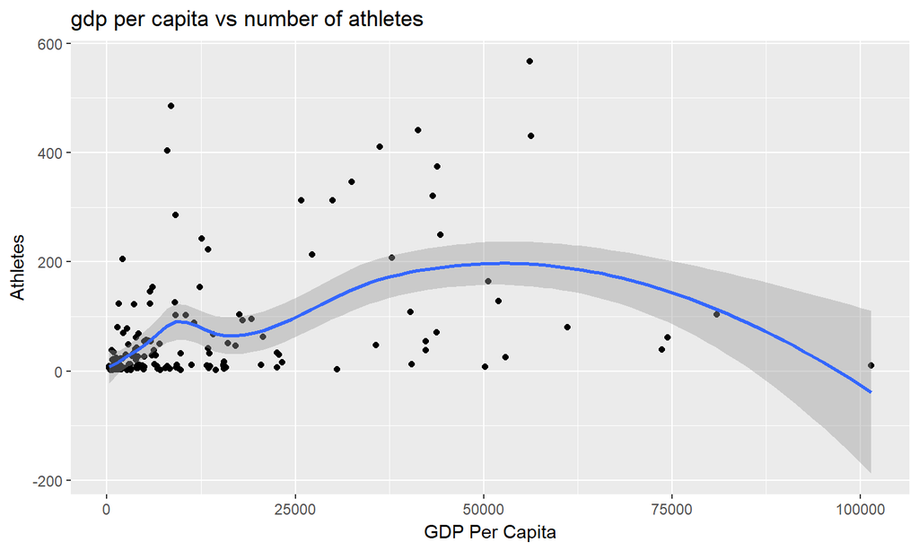

Medals distribution for 2016 Olympics

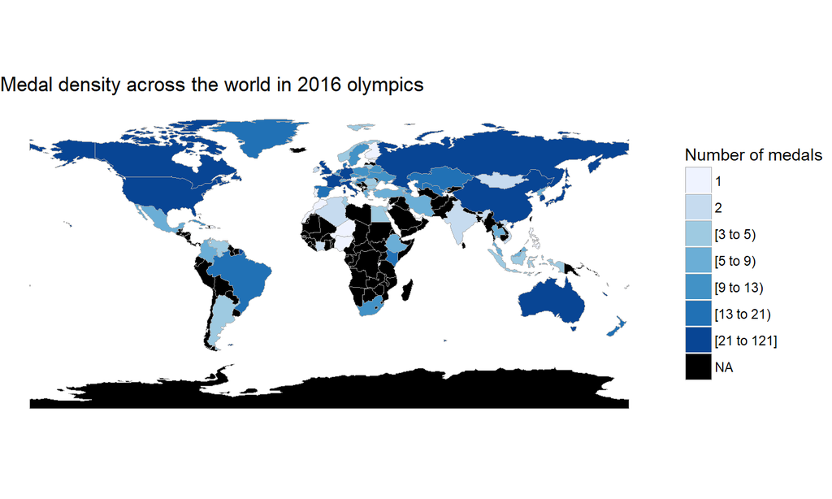

Medals distribution for overall Olympics

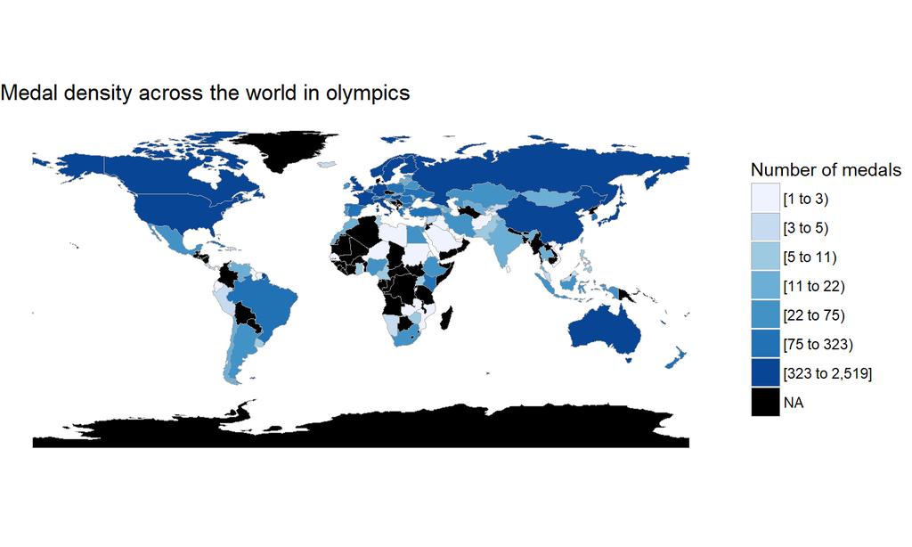